# CNN Image Classification Laboration

Images used in this laboration are from CIFAR 10 (https://en.wikipedia.org/wiki/CIFAR-10). The CIFAR-10 dataset contains 60,000 32x32 color images in 10 different classes. The 10 different classes represent airplanes, cars, birds, cats, deer, dogs, frogs, horses, ships, and trucks. There are 6,000 images of each class. Your task is to make a classifier, using a convolutional neural network, that can correctly classify each image into the correct class.

You need to answer all questions in this notebook.

## Part 1: What is a convolution

To understand a bit more about convolutions, we will first test the convolution function in scipy using a number of classical filters.

Convolve the image with Gaussian filter, a Sobel X filter, and a Sobel Y filter, using the function 'convolve2d' in 'signal' from scipy.

https://docs.scipy.org/doc/scipy/reference/generated/scipy.signal.convolve2d.html

In a CNN, many filters are applied in each layer, and the filter coefficients are learned through back propagation (which is in contrast to traditional image processing, where the filters are designed by an expert).

```python
# This cell is finished

from scipy import signal
import numpy as np

# Get a test image
from scipy import misc
image = misc.ascent()

# Define a help function for creating a Gaussian filter
def matlab_style_gauss2D(shape=(3,3),sigma=0.5):
    """
    2D gaussian mask - should give the same result as MATLAB's
    fspecial('gaussian',[shape],[sigma])
    """
    m,n = [(ss-1.)/2. for ss in shape]
    y,x = np.ogrid[-m:m+1,-n:n+1]
    h = np.exp( -(x*x + y*y) / (2.*sigma*sigma) )
    h[ h < np.finfo(h.dtype).eps*h.max() ] = 0
    sumh = h.sum()
    if sumh != 0:
        h /= sumh
    return h

# Create Gaussian filter with certain size and standard deviation
gaussFilter = matlab_style_gauss2D((15,15),4)

# Define filter kernels for SobelX and Sobely
sobelX = np.array([[ 1, 0,  -1],
                    [2, 0, -2],
                    [1, 0, -1]])

sobelY = np.array([[ 1, 2,  1],
                    [0, 0, 0],
                    [-1, -2, -1]])
```

```python
# Perform convolution using the function 'convolve2d' for the different filters
filterResponseGauss = signal.convolve2d(image,gaussFilter)

filterResponseSobelX = signal.convolve2d(image,sobelX)
filterResponseSobelY = signal.convolve2d(image,sobelY)
```

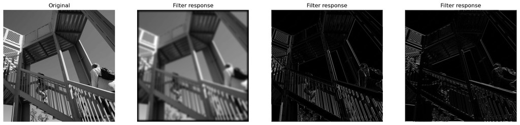

```python
import matplotlib.pyplot as plt

# Show filter responses
fig, (ax_orig, ax_filt1, ax_filt2, ax_filt3) = plt.subplots(1, 4, figsize=(20, 6))
ax_orig.imshow(image, cmap='gray')
ax_orig.set_title('Original')
ax_orig.set_axis_off()
ax_filt1.imshow(np.absolute(filterResponseGauss), cmap='gray')
ax_filt1.set_title('Filter response')
ax_filt1.set_axis_off()
ax_filt2.imshow(np.absolute(filterResponseSobelX), cmap='gray')
ax_filt2.set_title('Filter response')
ax_filt2.set_axis_off()
ax_filt3.imshow(np.absolute(filterResponseSobelY), cmap='gray')
ax_filt3.set_title('Filter response')
ax_filt3.set_axis_off()
```

## Part 2: Understanding convolutions

Question 1: What do the 3 different filters (Gaussian, SobelX, SobelY) do to the original image?

- Gaussian: blur the image
- SobelX : find edges horizontally
- SobelY : find edges vertically

Question 2: What is the size of the original image? How many channels does it have? How many channels does a color image normally have?

- size of the original image is 512x512
- it's grayscale image thus it has 1 channel
- a color image normally have 3 channels: RGB

Question 3: What is the size of the different filters?

- Gaussian: 15x15
- SobelX : 3x3
- SobelY : 3x3

Question 4: What is the size of the filter response if mode 'same' is used for the convolution ?

- mode = 'same':The output is the same size as in1, centered with respect to the ‘full’ output.
- the size of output will be 512x512, the same as input image.

Question 5: What is the size of the filter response if mode 'valid' is used for the convolution? How does the size of the valid filter response depend on the size of the filter?

Question 6: Why are 'valid' convolutions a problem for CNNs with many layers?

- it will reduce the dimensions of input by and by when we have many layers. We need to bear it in mind esspecially when we dont want such characteristic.

```python
# Your code for checking sizes of image and filter responses
print(image.shape)
print(signal.convolve2d(image,gaussFilter,mode='same').shape)
print(signal.convolve2d(image,gaussFilter,mode='valid').shape)
```

[output not shown]

## Part 3: Get a graphics card

Skip this part if you run on a CPU (recommended)

Let's make sure that our script can see the graphics card that will be used. The graphics cards will perform all the time consuming convolutions in every training iteration.

```python
import os
import warnings

# Ignore FutureWarning from numpy
warnings.simplefilter(action='ignore', category=FutureWarning)

import keras.backend as K
import tensorflow as tf

os.environ["CUDA_DEVICE_ORDER"]="PCI_BUS_ID";

# The GPU id to use, usually either "0" or "1";
os.environ["CUDA_VISIBLE_DEVICES"]="0";

# Allow growth of GPU memory, otherwise it will always look like all the memory is being used
physical_devices = tf.config.experimental.list_physical_devices('GPU')
tf.config.experimental.set_memory_growth(physical_devices[0], True)
```

## Part 4: How fast is the graphics card?

Question 7: Why are the filters used for a color image of size 7 x 7 x 3, and not 7 x 7 ?

- there're 3 channels(RGB) for color image besides image sieze 7x7

Question 8: What operation is performed by the 'Conv2D' layer? Is it a standard 2D convolution, as performed by the function signal.convolve2d we just tested?

- in 'Conv2D', it's using crosscorrelation, instead of standard 2D convolution

Question 9: Do you think that a graphics card, compared to the CPU, is equally faster for convolving a batch of 1,000 images, compared to convolving a batch of 3 images? Motivate your answer.

- yes, graphics card is good at compute massive simples tasks parallelly, compared to the CPU, which has more powerful but much less cores than GPU

## Part 5: Load data

Time to make a 2D CNN. Load the images and labels from keras.datasets, this cell is already finished.

```python
from keras.datasets import cifar10
import numpy as np

classes = ['plane', 'car', 'bird', 'cat', 'deer', 'dog', 'frog', 'horse', 'ship', 'truck']

# Download CIFAR train and test data
(Xtrain, Ytrain), (Xtest, Ytest) = cifar10.load_data()

print("Training images have size {} and labels have size {} ".format(Xtrain.shape, Ytrain.shape))
print("Test images have size {} and labels have size {} \n ".format(Xtest.shape, Ytest.shape))

# Reduce the number of images for training and testing to 10000 and 2000 respectively,
# to reduce processing time for this laboration
Xtrain = Xtrain[0:10000]
Ytrain = Ytrain[0:10000]

Xtest = Xtest[0:2000]
Ytest = Ytest[0:2000]

Ytestint = Ytest

print("Reduced training images have size %s and labels have size %s " % (Xtrain.shape, Ytrain.shape))
print("Reduced test images have size %s and labels have size %s \n" % (Xtest.shape, Ytest.shape))

# Check that we have some training examples from each class
for i in range(10):
    print("Number of training examples for class {} is {}" .format(i,np.sum(Ytrain == i)))
```

```
Training images have size (50000, 32, 32, 3) and labels have size (50000, 1)
Test images have size (10000, 32, 32, 3) and labels have size (10000, 1)

Reduced training images have size (10000, 32, 32, 3) and labels have size (10000, 1)
Reduced test images have size (2000, 32, 32, 3) and labels have size (2000, 1)

Number of training examples for class 0 is 1005
Number of training examples for class 1 is 974
Number of training examples for class 2 is 1032
Number of training examples for class 3 is 1016
Number of training examples for class 4 is 999
Number of training examples for class 5 is 937
Number of training examples for class 6 is 1030
Number of training examples for class 7 is 1001
Number of training examples for class 8 is 1025
Number of training examples for class 9 is 981
```

## Part 6: Plotting

Lets look at some of the training examples, this cell is already finished. You will see different examples every time you run the cell.

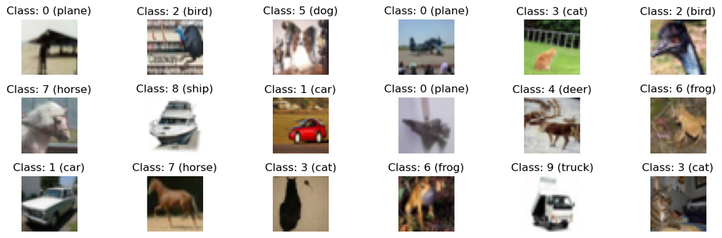

```python
import matplotlib.pyplot as plt

plt.figure(figsize=(12,4))
for i in range(18):
    idx = np.random.randint(7500)
    label = Ytrain[idx,0]

    plt.subplot(3,6,i+1)
    plt.tight_layout()
    plt.imshow(Xtrain[idx])
    plt.title("Class: {} ({})".format(label, classes[label]))
    plt.axis('off')
plt.show()
```

## Part 7: Split data into training, validation and testing

https://scikit-learn.org/stable/modules/generated/sklearn.model_selection.train_test_split.html

```python
from sklearn.model_selection import train_test_split

# Your code for splitting the dataset
Xtrain, Xval, Ytrain, Yval = train_test_split(Xtrain, Ytrain, test_size=0.3, random_state=42)
# Print the size of training data, validation data and test data
for set in (Xtrain, Xval, Ytrain, Yval):
    print(f'{set.shape}')
```

```
(7000, 32, 32, 3)
(3000, 32, 32, 3)
(7000, 1)
(3000, 1)
```

## Part 8: Preprocessing of images

Lets perform some preprocessing. The images are stored as uint8, i.e. 8 bit unsigned integers, but need to be converted to 32 bit floats. We also make sure that the range is -1 to 1, instead of 0 - 255. This cell is already finished.

```python
# Convert datatype for Xtrain, Xval, Xtest, to float32
Xtrain = Xtrain.astype('float32')
Xval = Xval.astype('float32')
Xtest = Xtest.astype('float32')

# Change range of pixel values to [-1,1]
Xtrain = Xtrain / 127.5 - 1
Xval = Xval / 127.5 - 1
Xtest = Xtest / 127.5 - 1
```

## Part 9: Preprocessing of labels

The labels (Y) need to be converted from e.g. '4' to "hot encoded", i.e. to a vector of type [0, 0, 0, 1, 0, 0, 0, 0, 0, 0] . We use a function in Keras, see https://keras.io/api/utils/python_utils/#to_categorical-function

```python
from tensorflow.keras.utils import to_categorical

# for set in (Ytrain, Yval, Ytest):
# # Print shapes before converting the labels
#     print('before converting',set.shape)
# # Your code for converting Ytrain, Yval, Ytest to categorical
#     set = to_categorical(set, num_classes=len(classes))
# # Print shapes after converting the labels
#     print('after converting',set.shape)

# for set in (Ytrain, Yval, Ytest):
#     print('after converting',set.shape)
# # work only within the loop, why?
print(f'Ytrain.shape = {Ytrain.shape}')
print(f'Yval.shape = {Yval.shape}')
print(f'Ytest.shape = {Ytest.shape}')

Ytrain = to_categorical(Ytrain, num_classes=len(classes))
Yval = to_categorical(Yval, num_classes=len(classes))
Ytest = to_categorical(Ytest, num_classes=len(classes))

print('after converting:')

print(f'Ytrain.shape = {Ytrain.shape}')
print(f'Yval.shape = {Yval.shape}')
print(f'Ytest.shape = {Ytest.shape}')
```

```
Ytrain.shape = (7000, 1)
Yval.shape = (3000, 1)
Ytest.shape = (2000, 1)
after converting:
Ytrain.shape = (7000, 10)
Yval.shape = (3000, 10)
Ytest.shape = (2000, 10)
```

## Part 10: 2D CNN

Finish this code to create the image classifier, using a 2D CNN. Each convolutional layer will contain 2D convolution, batch normalization and max pooling. After the convolutional layers comes a flatten layer and a number of intermediate dense layers. The convolutional layers should take the number of filters as an argument, use a kernel size of 3 x 3, 'same' padding, and relu activation functions. The number of filters will double with each convolutional layer. The max pooling layers should have a pool size of 2 x 2. The intermediate dense layers before the final dense layer should take the number of nodes as an argument, use relu activation functions, and be followed by batch normalization. The final dense layer should have 10 nodes (= the number of classes in this laboration) and 'softmax' activation. Here we start with the Adam optimizer.

Relevant functions are

`model.add()`, adds a layer to the network

`Dense()`, a dense network layer

`Conv2D()`, performs 2D convolutions with a number of filters with a certain size (e.g. 3 x 3).

`BatchNormalization()`, perform batch normalization

`MaxPooling2D()`, saves the max for a given pool size, results in down sampling

`Flatten()`, flatten a multi-channel tensor into a long vector

`model.compile()`, compile the model, add " metrics=['accuracy'] " to print the classification accuracy during the training

See https://keras.io/api/layers/core_layers/dense/ and https://keras.io/api/layers/reshaping_layers/flatten/ for information on how the `Dense()` and `Flatten()` functions work

See https://keras.io/layers/convolutional/ for information on how `Conv2D()` works

See https://keras.io/layers/pooling/ for information on how `MaxPooling2D()` works

Import a relevant cost function for multi-class classification from keras.losses (https://keras.io/losses/) , it relates to how many classes you have.

See the following links for how to compile, train and evaluate the model

https://keras.io/api/models/model_training_apis/#compile-method

https://keras.io/api/models/model_training_apis/#fit-method

https://keras.io/api/models/model_training_apis/#evaluate-method

```python
from keras.models import Sequential, Model
from keras.layers import Input, Conv2D, BatchNormalization, MaxPooling2D, Flatten, Dense, Dropout
from tensorflow.keras.optimizers import Adam
from keras.losses import CategoricalCrossentropy

# Set seed from random number generator, for better comparisons
from numpy.random import seed
seed(123)

def build_CNN(input_shape, n_conv_layers=2, n_filters=16, n_dense_layers=0, n_nodes=50, use_dropout=False, learning_rate=0.01):

    # Setup a sequential model
    model = Sequential()

    # Add first convolutional layer to the model, requires input shape
    # model.add(Input(shape=input_shape))
    model.add(Conv2D(filters= (1)*n_filters, kernel_size=(3,3), padding='same',activation='relu',input_shape= input_shape))
    model.add(BatchNormalization())
    model.add(MaxPooling2D(pool_size=(2,2)))

    # Add remaining convolutional layers to the model, the number of filters should increase a factor 2 for each layer
    for i in range(n_conv_layers-1):
        model.add(Conv2D(filters= (2**(i+1))*n_filters, kernel_size=(3,3), padding='same',activation='relu'))
        model.add(BatchNormalization())
        model.add(MaxPooling2D(pool_size=(2,2)))

    # Add flatten layer
    model.add(Flatten())

    # Add intermediate dense layers
    for i in range(n_dense_layers):
        model.add(Dense(n_nodes, activation='relu'))
        model.add(BatchNormalization())

        if use_dropout:
            if use_dropout == True:
                use_dropout = 0.5
            model.add(Dropout(rate = use_dropout))

    # Add final dense layer
    model.add(Dense(10,activation='softmax'))

    # Compile model
    optimizer = Adam(learning_rate=learning_rate)

    model.compile(loss='categorical_crossentropy', optimizer=optimizer, metrics=['accuracy'])


    return model
```

```python
# Lets define a help function for plotting the training results
import matplotlib.pyplot as plt
def plot_results(history):

    loss = history.history['loss']
    acc = history.history['accuracy']
    val_loss = history.history['val_loss']
    val_acc = history.history['val_accuracy']

    plt.figure(figsize=(10,4))
    plt.xlabel('Epochs')
    plt.ylabel('Loss')
    plt.plot(loss)
    plt.plot(val_loss)
    plt.legend(['Training','Validation'])

    plt.figure(figsize=(10,4))
    plt.xlabel('Epochs')
    plt.ylabel('Accuracy')
    plt.plot(acc)
    plt.plot(val_acc)
    plt.legend(['Training','Validation'])

    plt.show()
```

## Part 11: Train 2D CNN

Time to train the 2D CNN, start with 2 convolutional layers, no intermediate dense layers, learning rate = 0.01. The first convolutional layer should have 16 filters (which means that the second convolutional layer will have 32 filters).

Relevant functions

`build_CNN`, the function we defined in Part 10, call it with the parameters you want to use

`model.fit()`, train the model with some training data

`model.evaluate()`, apply the trained model to some test data

See the following links for how to train and evaluate the model

https://keras.io/api/models/model_training_apis/#fit-method

https://keras.io/api/models/model_training_apis/#evaluate-method

## 2 convolutional layers, no intermediate dense layers

```python
# Setup some training parameters
batch_size = 100
epochs = 20
input_shape = Xtrain.shape[1:]

# Build model
model1 = build_CNN(input_shape,n_conv_layers=2,n_dense_layers=0)

# Train the model  using training data and validation data
history1 = model1.fit(Xtrain,Ytrain,epochs=epochs, batch_size=batch_size,validation_data=(Xval,Yval))
```

```python
# Evaluate the trained model on test set, not used in training or validation
score = model1.evaluate(Xtest,Ytest, batch_size=batch_size)
print('Test loss: %.4f' % score[0])
print('Test accuracy: %.4f' % score[1])
```

```
Test loss: 3.0714
Test accuracy: 0.5410
```

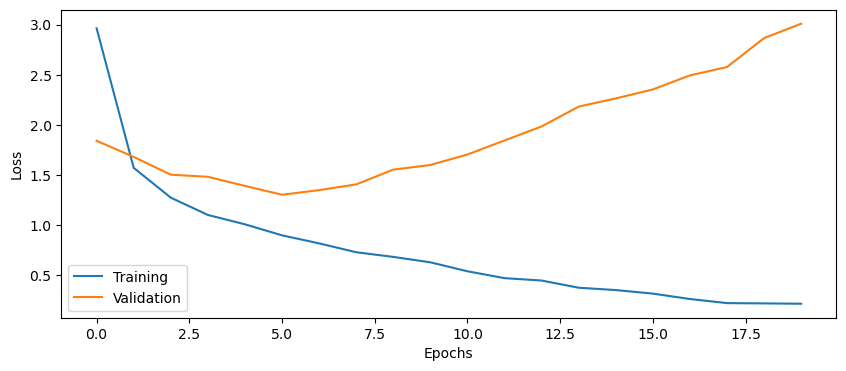

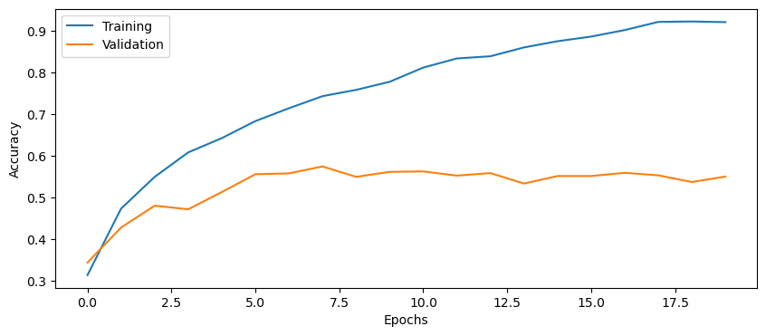

```python
# Plot the history from the training run
plot_results(history1)
```

```python
model1.summary()
```

```
Model: "sequential_11"
_________________________________________________________________
Layer (type)                 Output Shape              Param #
=================================================================
conv2d_24 (Conv2D)           (None, 32, 32, 16)        448
_________________________________________________________________
batch_normalization_24 (Batc (None, 32, 32, 16)        64
_________________________________________________________________
max_pooling2d_22 (MaxPooling (None, 16, 16, 16)        0
_________________________________________________________________
conv2d_25 (Conv2D)           (None, 16, 16, 32)        4640
_________________________________________________________________
batch_normalization_25 (Batc (None, 16, 16, 32)        128
_________________________________________________________________
max_pooling2d_23 (MaxPooling (None, 8, 8, 32)          0
_________________________________________________________________
flatten_10 (Flatten)         (None, 2048)              0
_________________________________________________________________
dense_12 (Dense)             (None, 10)                20490
=================================================================
Total params: 25,770
Trainable params: 25,674
Non-trainable params: 96
_________________________________________________________________
```

## Part 12: Improving performance

Write down the test accuracy, are you satisfied with the classifier performance (random chance is 10%) ?

- Test accuracy: 0.5410
- better than random chance, but still far away from satisfing. severe overfitting needs to be mitigated

Question 10: How big is the difference between training and test accuracy?

- training accuracy: 0.9203
- difference: 0.3793

Question 11: For the DNN laboration we used a batch size of 10,000, why do we need to use a smaller batch size in this laboration?

- there're much more parameters than DNN, which needs more space occupied in the momory under same batch size.

## 2 convolutional layers, 1 intermediate dense layer (50 nodes)

```python
# Setup some training parameters
batch_size = 100
epochs = 20
input_shape = Xtrain.shape[1:]

# Build model
model2 = build_CNN(input_shape,n_conv_layers=2,n_dense_layers=1,n_nodes=50)

# Train the model  using training data and validation data
history2 = model2.fit(Xtrain,Ytrain,epochs=epochs, batch_size=batch_size,validation_data=(Xval,Yval))
```

```python
# Evaluate the trained model on test set, not used in training or validation
score = model2.evaluate(Xtest,Ytest, batch_size=batch_size)
print('Test loss: %.4f' % score[0])
print('Test accuracy: %.4f' % score[1])
```

```
Test loss: 3.2746
Test accuracy: 0.5555
```

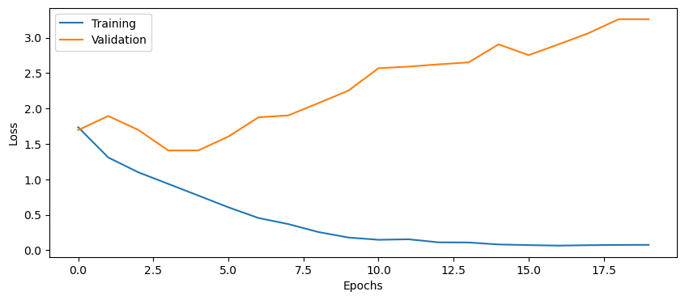

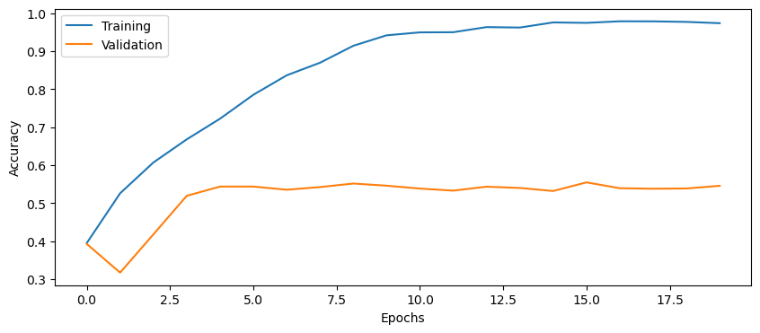

```python
# Plot the history from the training run
plot_results(history2)
```

## 4 convolutional layers, 1 intermediate dense layer (50 nodes)

```python
# Setup some training parameters
batch_size = 100
epochs = 20
input_shape = Xtrain.shape[1:]

# Build model
model3 = build_CNN(input_shape,n_conv_layers=4,n_dense_layers=1,n_nodes=50)

# Train the model  using training data and validation data
history3 = model3.fit(Xtrain,Ytrain,epochs=epochs, batch_size=batch_size,validation_data=(Xval,Yval))
```

```python
# Evaluate the trained model on test set, not used in training or validation
score = model3.evaluate(Xtest,Ytest, batch_size=batch_size)
print('Test loss: %.4f' % score[0])
print('Test accuracy: %.4f' % score[1])
```

```
Test loss: 2.7582
Test accuracy: 0.5745
```

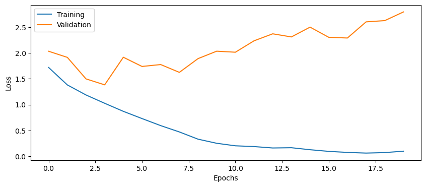

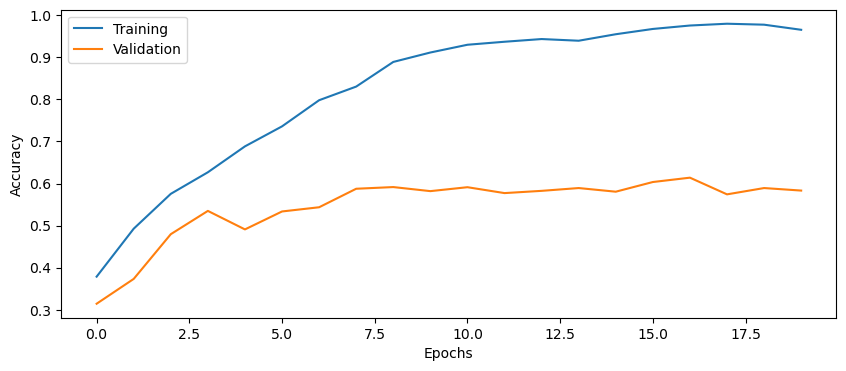

```python
# Plot the history from the training run
plot_results(history3)
```

## Part 13: Plot the CNN architecture

To understand your network better, print the architecture using `model.summary()`

Question 12: How many trainable parameters does your network have? Which part of the network contains most of the parameters?

- Trainable params: 124,180
- the last conv2D layer contains the most of the parameters

Question 13: What is the input to and output of a Conv2D layer? What are the dimensions of the input and output?

- the input is the output of last (max_pooling2d) layer
- the output is the same image dimension as input but with a doubled channels for each pixel

Question 14: Is the batch size always the first dimension of each 4D tensor? Check the documentation for Conv2D, https://keras.io/layers/convolutional/

- yes, batch_shape is always the first dimension of each 4D tensor. Whether data_format='channels_last' or data_format='channels_first'

Question 15: If a convolutional layer that contains 128 filters is applied to an input with 32 channels, what is the number of channels in the output?

- 128

Question 16: Why is the number of parameters in each Conv2D layer *not* equal to the number of filters times the number of filter coefficients per filter (plus biases)?

- there are input channels to be considered too

Question 17: How does MaxPooling help in reducing the number of parameters to train?

- with a default stride(default to pool_size) and padding(default to "valid"), it will pooling each 2x2 pixels into 1x1 non-overlappingly. and make 2nx2n image size dimensions reduced to nxn

```python
# Print network architecture

model3.summary()
```

```
Model: "sequential_13"
_________________________________________________________________
Layer (type)                 Output Shape              Param #
=================================================================
conv2d_28 (Conv2D)           (None, 32, 32, 16)        448
_________________________________________________________________
batch_normalization_29 (Batc (None, 32, 32, 16)        64
_________________________________________________________________
max_pooling2d_26 (MaxPooling (None, 16, 16, 16)        0
_________________________________________________________________
conv2d_29 (Conv2D)           (None, 16, 16, 32)        4640
_________________________________________________________________
batch_normalization_30 (Batc (None, 16, 16, 32)        128
_________________________________________________________________
max_pooling2d_27 (MaxPooling (None, 8, 8, 32)          0
_________________________________________________________________
conv2d_30 (Conv2D)           (None, 8, 8, 64)          18496
_________________________________________________________________
batch_normalization_31 (Batc (None, 8, 8, 64)          256
_________________________________________________________________
max_pooling2d_28 (MaxPooling (None, 4, 4, 64)          0
_________________________________________________________________
conv2d_31 (Conv2D)           (None, 4, 4, 128)         73856
_________________________________________________________________
batch_normalization_32 (Batc (None, 4, 4, 128)         512
_________________________________________________________________
max_pooling2d_29 (MaxPooling (None, 2, 2, 128)         0
_________________________________________________________________
flatten_12 (Flatten)         (None, 512)               0
_________________________________________________________________
dense_15 (Dense)             (None, 50)                25650
_________________________________________________________________
batch_normalization_33 (Batc (None, 50)                200
_________________________________________________________________
dense_16 (Dense)             (None, 10)                510
=================================================================
Total params: 124,760
Trainable params: 124,180
Non-trainable params: 580
_________________________________________________________________
```

## Part 14: Dropout regularization

Add dropout regularization between each intermediate dense layer, dropout probability 50%.

Question 18: How much did the test accuracy improve with dropout, compared to without dropout?

- without : Test accuracy: 0.5745
- with : Test accuracy: 0.5780
- minor improve for this 2 runs, but can be better

Question 19: What other types of regularization can be applied? How can you add L2 regularization for the convolutional layers?

- L1/L2 regularization
- we can add augment kernel_regularizer/bias_regularizer/activity_regularizer = 'l2' to conv2D

## 4 convolutional layers, 1 intermediate dense layer (50 nodes), dropout

```python
# Setup some training parameters
batch_size = 100
epochs = 20
input_shape = Xtrain.shape[1:]

# Build model
model4 = build_CNN(input_shape,n_conv_layers=4,n_dense_layers=1,n_nodes=50, use_dropout=True)

# Train the model  using training data and validation data
history4 = model4.fit(Xtrain,Ytrain,epochs=epochs, batch_size=batch_size,validation_data=(Xval,Yval))
```

```python
# Evaluate the trained model on test set, not used in training or validation
score = model4.evaluate(Xtest,Ytest, batch_size=batch_size)
print('Test loss: %.4f' % score[0])
print('Test accuracy: %.4f' % score[1])
```

```
Test loss: 2.2668
Test accuracy: 0.5780
```

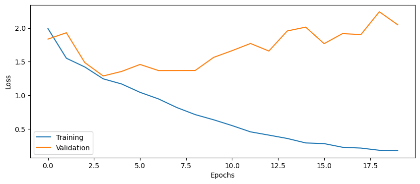

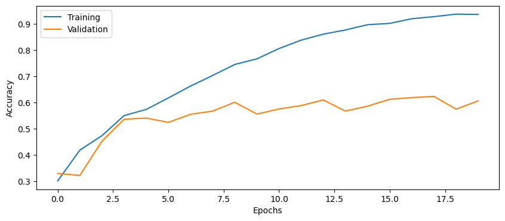

```python
# Plot the history from the training run
plot_results(history4)
```

## Part 15: Tweaking performance

You have now seen the basic building blocks of a 2D CNN. To further improve performance involves changing the number of convolutional layers, the number of filters per layer, the number of intermediate dense layers, the number of nodes in the intermediate dense layers, batch size, learning rate, number of epochs, etc. Spend some time (30 - 90 minutes) testing different settings.

Question 20: How high test accuracy can you obtain? What is your best configuration?

- Test accuracy: 0.4895
- higher acuracy can be expected with more epochs(and maybe a lower learning rate) but no further experiment here due to time constraints.
- parameters:
- batch_size = 5
- epochs = 40
- n_conv_layers=4,n_dense_layers=2,n_nodes=200, use_dropout=0.6

## Your best config

```python
# Setup some training parameters
batch_size = 5
epochs = 40
input_shape = Xtrain.shape[1:]

# Build model
model5 = build_CNN(input_shape,n_conv_layers=4,n_dense_layers=2,n_nodes=200, use_dropout=0.6)

# Train the model  using training data and validation data
history5 = model5.fit(Xtrain,Ytrain,epochs=epochs, batch_size=batch_size,validation_data=(Xval,Yval))
```

```python
# Evaluate the trained model on test set, not used in training or validation
score = model5.evaluate(Xtest,Ytest, batch_size=batch_size)
print('Test loss: %.4f' % score[0])
print('Test accuracy: %.4f' % score[1])
```

```
Test loss: 1006.8397
Test accuracy: 0.4895
```

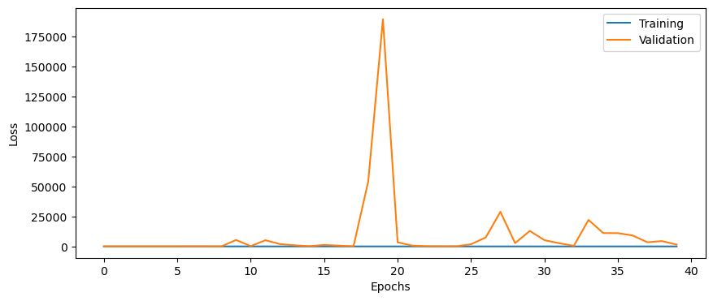

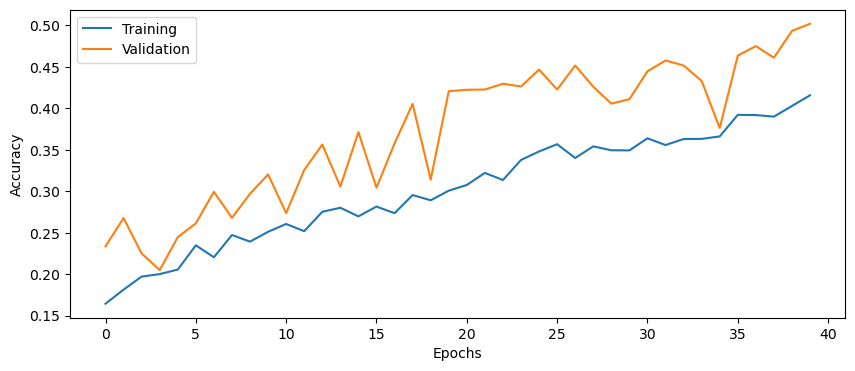

```python
# Plot the history from the training run
plot_results(history5)
```

## Part 16: Rotate the test images

How high is the test accuracy if we rotate the test images? In other words, how good is the CNN at generalizing to rotated images?

Rotate each test image 90 degrees, the cells are already finished.

Question 21: What is the test accuracy for rotated test images, compared to test images without rotation? Explain the difference in accuracy.

```python
def myrotate(images):

    images_rot = np.rot90(images, axes=(1,2))

    return images_rot
```

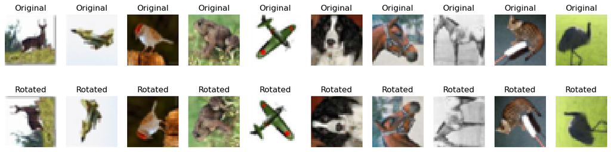

```python
# Rotate the test images 90 degrees
Xtest_rotated = myrotate(Xtest)

# Look at some rotated images
plt.figure(figsize=(16,4))
for i in range(10):
    idx = np.random.randint(500)

    plt.subplot(2,10,i+1)
    plt.imshow(Xtest[idx]/2+0.5)
    plt.title("Original")
    plt.axis('off')

    plt.subplot(2,10,i+11)
    plt.imshow(Xtest_rotated[idx]/2+0.5)
    plt.title("Rotated")
    plt.axis('off')
plt.show()
```

```python
# Evaluate the trained model on rotated test set
score = model5.evaluate(Xtest_rotated,Ytest, batch_size=batch_size)
print('Test loss: %.4f' % score[0])
print('Test accuracy: %.4f' % score[1])
```

```
Test loss: 1390.1122
Test accuracy: 0.2040
```

## Part 17: Augmentation using Keras `ImageDataGenerator`

We can increase the number of training images through data augmentation (we now ignore that CIFAR10 actually has 60 000 training images). Image augmentation is about creating similar images, by performing operations such as rotation, scaling, elastic deformations and flipping of existing images. This will prevent overfitting, especially if all the training images are in a certain orientation.

We will perform the augmentation on the fly, using a built-in function in Keras, called `ImageDataGenerator`

See https://www.tensorflow.org/api_docs/python/tf/keras/preprocessing/image/ImageDataGenerator , the .flow(x,y) functionality

Make sure to use different subsets for training and validation when you setup the flows, otherwise you will validate on the same data...

```python
# Get all 60 000 training images again. ImageDataGenerator manages validation data on its own
(Xtrain, Ytrain), _ = cifar10.load_data()

# Reduce number of images to 10,000
Xtrain = Xtrain[0:10000]
Ytrain = Ytrain[0:10000]

# Change data type and rescale range
Xtrain = Xtrain.astype('float32')
Xtrain = Xtrain / 127.5 - 1

# Convert labels to hot encoding
Ytrain = to_categorical(Ytrain, 10)
```

```python
# Set up a data generator with on-the-fly data augmentation, 20% validation split
# Use a rotation range of 30 degrees, horizontal and vertical flipping
from keras.preprocessing.image import ImageDataGenerator

datagen = ImageDataGenerator(rotation_range=0.3,horizontal_flip=True, vertical_flip=True,validation_split=0.2)

datagen.fit(Xtrain)

# Setup a flow for training data, assume that we can fit all images into CPU memory
datagen.flow(x=Xtrain,y=Ytrain, subset='training')

# Setup a flow for validation data, assume that we can fit all images into CPU memory
datagen.flow(x=Xtrain,y=Ytrain, subset='validation')
```

```
<tensorflow.python.keras.preprocessing.image.NumpyArrayIterator at 0x2230297b488>
```

## Part 18: What about big data?

Question 22: How would you change the code for the image generator if you cannot fit all training images in CPU memory? What is the disadvantage of doing that change?

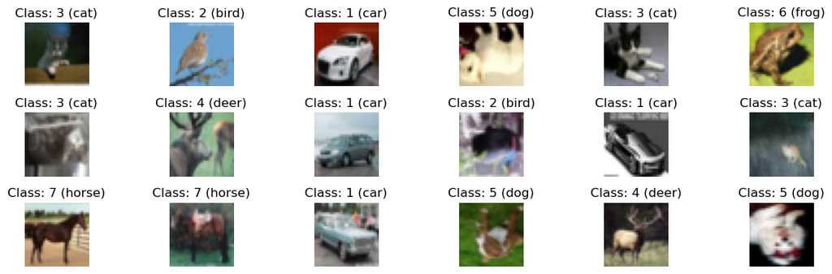

```python
# Plot some augmented images
plot_datagen = datagen.flow(Xtrain, Ytrain, batch_size=1)

plt.figure(figsize=(12,4))
for i in range(18):
    (im, label) = plot_datagen.next()
    im = (im[0] + 1) * 127.5
    im = im.astype('int')
    label = np.flatnonzero(label)[0]

    plt.subplot(3,6,i+1)
    plt.tight_layout()
    plt.imshow(im)
    plt.title("Class: {} ({})".format(label, classes[label]))
    plt.axis('off')
plt.show()
```

## Part 19: Train the CNN with images from the generator

See https://keras.io/api/models/model_training_apis/#fit-method for how to use model.fit with a generator instead of a fix dataset (numpy arrays)

To make the comparison fair to training without augmentation

```
steps_per_epoch should be set to: len(Xtrain)*(1 - validation_split)/batch_size

validation_steps should be set to: len(Xtrain)*validation_split/batch_size
```

This is required since with a generator, the fit function will not know how many examples your original dataset has.

Question 23: How quickly is the training accuracy increasing compared to without augmentation? Explain why there is a difference compared to without augmentation. We are here talking about the number of training epochs required to reach a certain accuracy, and not the training time in seconds. What parameter is necessary to change to perform more training?

- the training accuracy increasing much more slower than without augmentation
- the reversed/rotated images(but with same label) put an extra obstacle towards learning, which makes the model takes loger time to learn
- more epochs will perform more traings

Question 24: What other types of image augmentation can be applied, compared to what we use here?

- scale/translation/quality/color augmentation

```python
# Setup some training parameters
batch_size = 100
epochs = 200
input_shape = Xtrain.shape[1:]

# Build model (your best config)
# again for time considerations we are using:
# 4 convolutional layers, 1 intermediate dense layer (50 nodes), dropout
# and disscusstion/comparision is of course based on that
model6 = build_CNN(input_shape, n_conv_layers=4,n_dense_layers=1,n_nodes=50, use_dropout=True)

validation_split=0.2

# Train the model using on the fly augmentation
history6 = model6.fit(datagen.flow(x=Xtrain,y=Ytrain, subset='training',batch_size=batch_size),\
                      validation_data = datagen.flow(x=Xtrain,y=Ytrain, subset='validation',batch_size=batch_size),\
                      steps_per_epoch = len(Xtrain)*(1 - validation_split)/batch_size,\
                      validation_steps = len(Xtrain)*validation_split/batch_size,\
                      epochs=epochs)
```

```python
# Check if there is still a big difference in accuracy for original and rotated test images

# Evaluate the trained model on original test set
score = model6.evaluate(Xtest, Ytest, batch_size = batch_size, verbose=0)
print('Test loss: %.4f' % score[0])
print('Test accuracy: %.4f' % score[1])

# Evaluate the trained model on rotated test set
score = model6.evaluate(Xtest_rotated, Ytest, batch_size = batch_size, verbose=0)
print('Test loss: %.4f' % score[0])
print('Test accuracy: %.4f' % score[1])
```

```
Test loss: 2.3961
Test accuracy: 0.6185
Test loss: 6.8235
Test accuracy: 0.2560
```

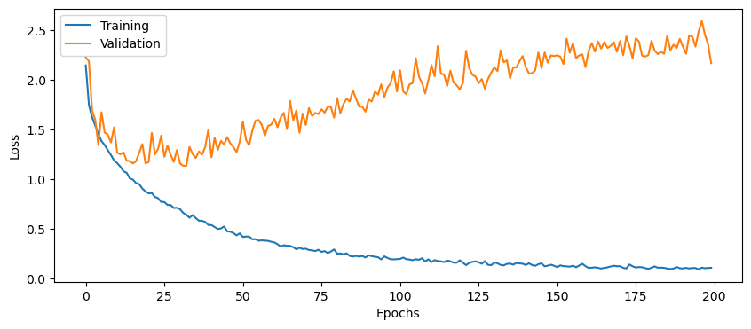

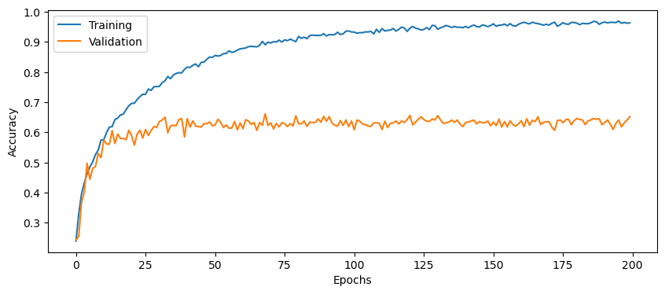

```python
# Plot the history from the training run
plot_results(history6)
```

## Part 20: Plot misclassified images

Lets plot some images where the CNN performed badly, these cells are already finished.

```python
# Find misclassified images
y_pred=model6.predict(Xtest)
y_pred=np.argmax(y_pred,axis=1)

y_correct = np.argmax(Ytest,axis=-1)

miss = np.flatnonzero(y_correct != y_pred)
```

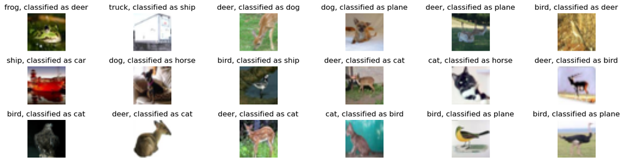

```python
# Plot a few of them
plt.figure(figsize=(15,4))
perm = np.random.permutation(miss)
for i in range(18):
    im = (Xtest[perm[i]] + 1) * 127.5
    im = im.astype('int')
    label_correct = y_correct[perm[i]]
    label_pred = y_pred[perm[i]]

    plt.subplot(3,6,i+1)
    plt.tight_layout()
    plt.imshow(im)
    plt.axis('off')
    plt.title("{}, classified as {}".format(classes[label_correct], classes[label_pred]))
plt.show()
```

## Part 21: Testing on another size

Question 25: This CNN has been trained on 32 x 32 images, can it be applied to images of another size? If not, why is this the case?

- no, the input parameter will be different(also the flattened fatures) and the trained parameters(e.g. weights of dense layer) wont work at all for a different input dimension

Question 26: Is it possible to design a CNN that can be trained on images of one size, and then applied to an image of any size? How?

- it might be possible via making the convolution/pooling layers dynamic and output the same flattened dimensions

## Part 22: Pre-trained 2D CNNs

There are many deep 2D CNNs that have been pre-trained using the large ImageNet database (several million images, 1000 classes). Import a pre-trained ResNet50 network from Keras applications. Show the network using `model.summary()`

Question 27: How many convolutional layers does ResNet50 have?

Question 28: How many trainable parameters does the ResNet50 network have?

- Trainable params: 25,583,592

Question 29: What is the size of the images that ResNet50 expects as input?

- 224, 224

Question 30: Using the answer to question 28, explain why the second derivative is seldom used when training deep networks.

- it will increase the number of Trainable params multiplicatively, and it will be extra horrofying when we have too much nodes in layers

Apply the pre-trained CNN to 5 random color images that you download and copy to the cloud machine or your own computer. Are the predictions correct? How certain is the network of each image class?

These pre-trained networks can be fine tuned to your specific data, and normally only the last layers need to be re-trained, but it will still be too time consuming to do in this laboration.

See https://keras.io/api/applications/ and https://keras.io/api/applications/resnet/#resnet50-function

Useful functions

`image.load_img` in tensorflow.keras.preprocessing

`image.img_to_array` in tensorflow.keras.preprocessing

`ResNet50` in tensorflow.keras.applications.resnet50

`preprocess_input` in tensorflow.keras.applications.resnet50

`decode_predictions` in tensorflow.keras.applications.resnet50

`expand_dims` in numpy

```python
# Your code for using pre-trained ResNet 50 on 5 color images of your choice.
# The preprocessing should transform the image to a size that is expected by the CNN.

from keras.models import Model
from keras.applications.resnet50 import ResNet50
from tensorflow.keras.preprocessing import image
from tensorflow.keras.applications.resnet50 import preprocess_input, decode_predictions
from numpy import expand_dims

model7 = ResNet50(weights='imagenet')
model7.summary()
```

```
Downloading data from https://storage.googleapis.com/tensorflow/keras-applications/resnet/resnet50_weights_tf_dim_ordering_tf_kernels.h5
Model: "resnet50"
__________________________________________________________________________________________________
Layer (type)                    Output Shape         Param #     Connected to
==================================================================================================
input_5 (InputLayer)            [(None, 224, 224, 3) 0
__________________________________________________________________________________________________
conv1_pad (ZeroPadding2D)       (None, 230, 230, 3)  0           input_5[0][0]
__________________________________________________________________________________________________
conv1_conv (Conv2D)             (None, 112, 112, 64) 9472        conv1_pad[0][0]
__________________________________________________________________________________________________
conv1_bn (BatchNormalization)   (None, 112, 112, 64) 256         conv1_conv[0][0]
__________________________________________________________________________________________________
conv1_relu (Activation)         (None, 112, 112, 64) 0           conv1_bn[0][0]
__________________________________________________________________________________________________
pool1_pad (ZeroPadding2D)       (None, 114, 114, 64) 0           conv1_relu[0][0]
__________________________________________________________________________________________________
pool1_pool (MaxPooling2D)       (None, 56, 56, 64)   0           pool1_pad[0][0]
__________________________________________________________________________________________________
conv2_block1_1_conv (Conv2D)    (None, 56, 56, 64)   4160        pool1_pool[0][0]
__________________________________________________________________________________________________
conv2_block1_1_bn (BatchNormali (None, 56, 56, 64)   256         conv2_block1_1_conv[0][0]
__________________________________________________________________________________________________
conv2_block1_1_relu (Activation (None, 56, 56, 64)   0           conv2_block1_1_bn[0][0]
__________________________________________________________________________________________________
conv2_block1_2_conv (Conv2D)    (None, 56, 56, 64)   36928       conv2_block1_1_relu[0][0]
__________________________________________________________________________________________________
conv2_block1_2_bn (BatchNormali (None, 56, 56, 64)   256         conv2_block1_2_conv[0][0]
__________________________________________________________________________________________________
conv2_block1_2_relu (Activation (None, 56, 56, 64)   0           conv2_block1_2_bn[0][0]
__________________________________________________________________________________________________
conv2_block1_0_conv (Conv2D)    (None, 56, 56, 256)  16640       pool1_pool[0][0]
__________________________________________________________________________________________________
conv2_block1_3_conv (Conv2D)    (None, 56, 56, 256)  16640       conv2_block1_2_relu[0][0]
__________________________________________________________________________________________________
conv2_block1_0_bn (BatchNormali (None, 56, 56, 256)  1024        conv2_block1_0_conv[0][0]
__________________________________________________________________________________________________
conv2_block1_3_bn (BatchNormali (None, 56, 56, 256)  1024        conv2_block1_3_conv[0][0]
__________________________________________________________________________________________________
conv2_block1_add (Add)          (None, 56, 56, 256)  0           conv2_block1_0_bn[0][0]
```

[output cut: 324 more lines]

```
conv5_block3_3_bn (BatchNormali (None, 7, 7, 2048)   8192        conv5_block3_3_conv[0][0]
__________________________________________________________________________________________________
conv5_block3_add (Add)          (None, 7, 7, 2048)   0           conv5_block2_out[0][0]
                                                                 conv5_block3_3_bn[0][0]
__________________________________________________________________________________________________
conv5_block3_out (Activation)   (None, 7, 7, 2048)   0           conv5_block3_add[0][0]
__________________________________________________________________________________________________
avg_pool (GlobalAveragePooling2 (None, 2048)         0           conv5_block3_out[0][0]
__________________________________________________________________________________________________
predictions (Dense)             (None, 1000)         2049000     avg_pool[0][0]
==================================================================================================
Total params: 25,636,712
Trainable params: 25,583,592
Non-trainable params: 53,120
__________________________________________________________________________________________________
```

```python
img_path = r'C:\Users\ni\Pictures\imagenet\val\ILSVRC2012_val_00000005.jpg'
img = image.load_img(img_path, target_size=(224, 224))
x = image.img_to_array(img)
x = np.expand_dims(x, axis=0)
x = preprocess_input(x)

preds = model7.predict(x)
# decode the results into a list of tuples (class, description, probability)
# (one such list for each sample in the batch)
print('Predicted:', decode_predictions(preds, top=3)[0])
```

[output not shown]

```python
img_path = r"C:\Users\ni\Pictures\imagenet\val\ILSVRC2012_val_00000004.jpg"
img = image.load_img(img_path, target_size=(224, 224))
x = image.img_to_array(img)
x = np.expand_dims(x, axis=0)
x = preprocess_input(x)

preds = model7.predict(x)
# decode the results into a list of tuples (class, description, probability)
# (one such list for each sample in the batch)
print('Predicted:', decode_predictions(preds, top=3)[0])
```

```
Predicted: [('n07920052', 'espresso', 0.52577883), ('n07930864', 'cup', 0.22489136), ('n03063599', 'coffee_mug', 0.13086708)]
```

```python
img_path = r'C:\Users\ni\Pictures\imagenet\val\ILSVRC2012_val_00000003.jpg'
img = image.load_img(img_path, target_size=(224, 224))
x = image.img_to_array(img)
x = np.expand_dims(x, axis=0)
x = preprocess_input(x)

preds = model7.predict(x)
# decode the results into a list of tuples (class, description, probability)
# (one such list for each sample in the batch)
print('Predicted:', decode_predictions(preds, top=3)[0])
```

```
Predicted: [('n02106030', 'collie', 0.98700887), ('n02105855', 'Shetland_sheepdog', 0.0119160265), ('n02090622', 'borzoi', 0.0008067721)]
```

```python
img_path = r'C:\Users\ni\Pictures\imagenet\val\ILSVRC2012_val_00000002.jpg'
img = image.load_img(img_path, target_size=(224, 224))
x = image.img_to_array(img)
x = np.expand_dims(x, axis=0)
x = preprocess_input(x)

preds = model7.predict(x)
# decode the results into a list of tuples (class, description, probability)
# (one such list for each sample in the batch)
print('Predicted:', decode_predictions(preds, top=3)[0])
```

```
Predicted: [('n04228054', 'ski', 0.83161676), ('n04208210', 'shovel', 0.14041887), ('n09193705', 'alp', 0.024471473)]
```

```python
img_path = r'C:\Users\ni\Pictures\imagenet\val\ILSVRC2012_val_00000001.jpg'
img = image.load_img(img_path, target_size=(224, 224))
x = image.img_to_array(img)
x = np.expand_dims(x, axis=0)
x = preprocess_input(x)

preds = model7.predict(x)
# decode the results into a list of tuples (class, description, probability)
# (one such list for each sample in the batch)
print('Predicted:', decode_predictions(preds, top=3)[0])
```

```
Predicted: [('n01751748', 'sea_snake', 0.6656197), ('n01729322', 'hognose_snake', 0.26146558), ('n01737021', 'water_snake', 0.03216641)]
```